# GenAI

Ellie Jeong

2023-11-05

## Data cleaning: 123 valid responses

```r
survey_c <- survey[-c(1:2),]
survey_c <- survey_c[,-c(10:13)] #remove recipient name, reference, email
survey_c <- survey_c[which(survey_c$Status != "Survey Preview"),] #remove survey preview and spam
survey_c <- survey_c[which(survey_c$Status != "Spam"),]

#Remove duplication
#1. identical responses to open-end questions (153 obs)
col <- c("Q34", "Q40", "Q27", "Q28")
dup_q <- survey_c[duplicated(survey_c[col]) | duplicated(survey_c[col], fromLast = TRUE), ]
survey_c <- survey_c %>%
  filter(!duplicated(survey_c[col]) & !duplicated(survey_c[col], fromLast = TRUE))
#survey_c <- survey_c[!duplicated(survey_c[,c("Q34","Q40","Q27","Q28")]),]

#2. identical email address (4 obs except for NAs)
dup_email <- survey_c %>% filter(duplicated(Q51) | duplicated(Q51, fromLast = TRUE))
filtered_survey_c <- survey_c %>%
  filter(is.na(Q51)|!duplicated(Q51) | !duplicated(Q51, fromLast = TRUE))

#3. keep duplicated IP address -> overall, responses are not identical (email address, open-end responses)
dup_ip <- survey_c %>% filter(duplicated(IPAddress) | duplicated(IPAddress, fromLast = TRUE))

#Exclusion criteria: no responses to section3 (values) & section4 (design aspirations)
survey_c <-survey_c %>% filter(!is.na(Q33_1))
```

## Descriptive statistics: frequency table, bar graph, pie chart

### Findings

- Experiences and needs for learning
  - Responses show that SE are helpful with learning as well as improving task performance.
  - The majority of respondents found GenAI most helpful with learning (attaining knowledge and skills) at workplaces.
  - Even people who have not thought about learning felt the need to attain knowledge and skills through GenAI.
- Usage patterns
  - The majority of SEs have experience in using diverse GenAI tools for workplace learning.
  - SEs often use various Gen AI tools when working.
- Needs (goals, values, design aspirations) and challenges
  - Responses show more diverse needs for GenAI that can be adopted in various phases of SE.
  - More user-centered needs and usage patterns (e.g., attain knowledge and skills, self-evaluating performances, decision-making) compared to task-centered needs that previous findings show (e.g., quickly executable assistance - solving problems, needs for documents and templates, finding information).
  - As GenAI is applied to diverse tasks and contexts, new types of needs (e.g., privacy, flexibility) emerge besides those related to performances (accuracy, reliability)

### Demographics

```
* Q42 - What is your age?
```

|  | Q42 | n | freq |
| --- | --- | --- | --- |
| 1 | 25-34 | 60 | 0.49 |
| 2 | 35-44 | 43 | 0.35 |
| 3 | 45-54 | 14 | 0.11 |
| 4 | 18-24 | 6 | 0.05 |

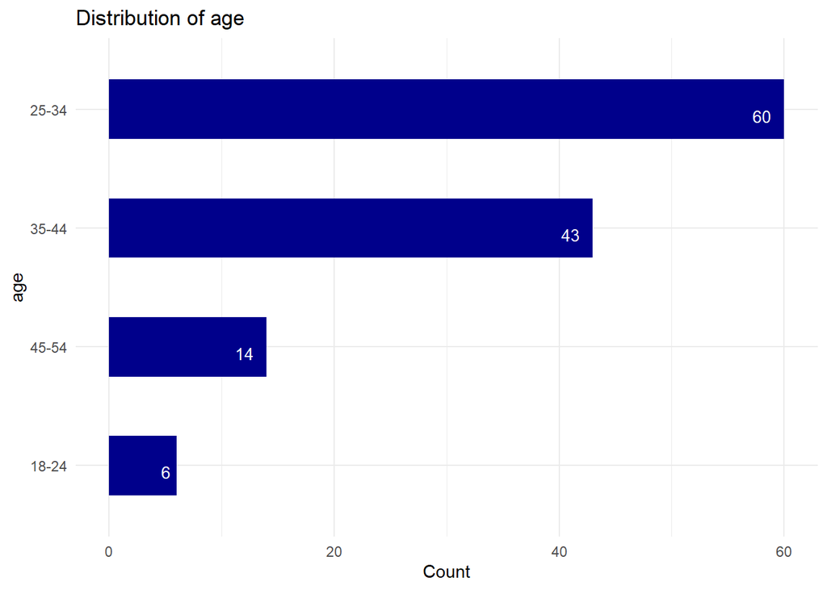

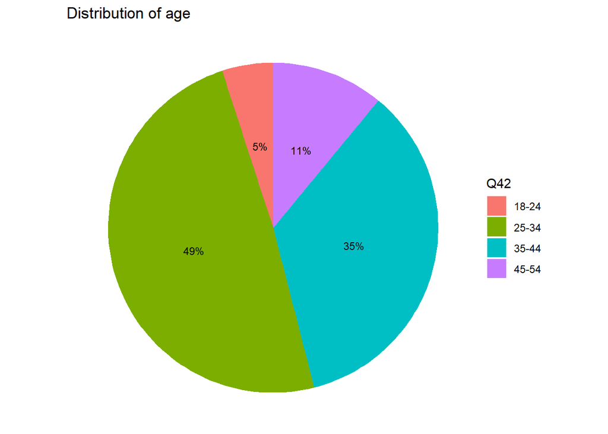

```
* Q43 - How do you identify your gender?
```

|  | Q43 | n | freq |
| --- | --- | --- | --- |
| 1 | Man | 90 | 0.73 |
| 2 | Woman | 32 | 0.26 |
| 3 | Nonbinary | 1 | 0.01 |

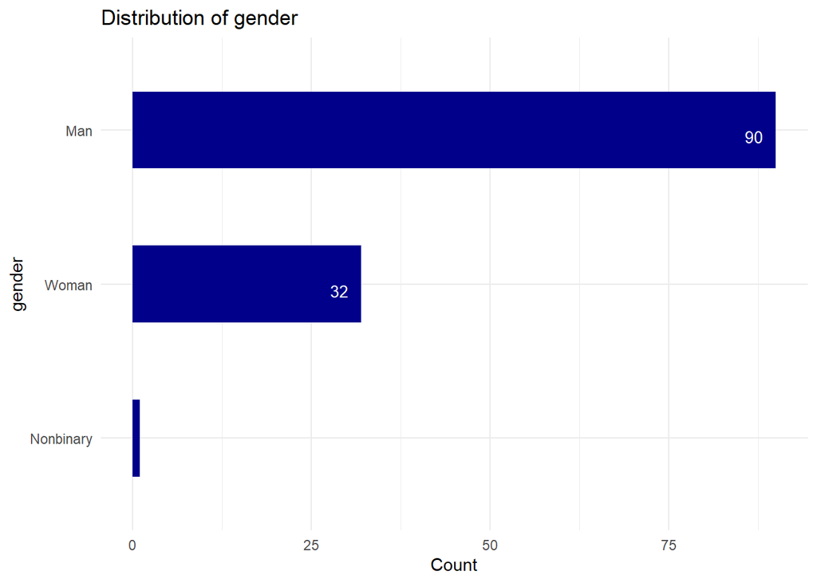

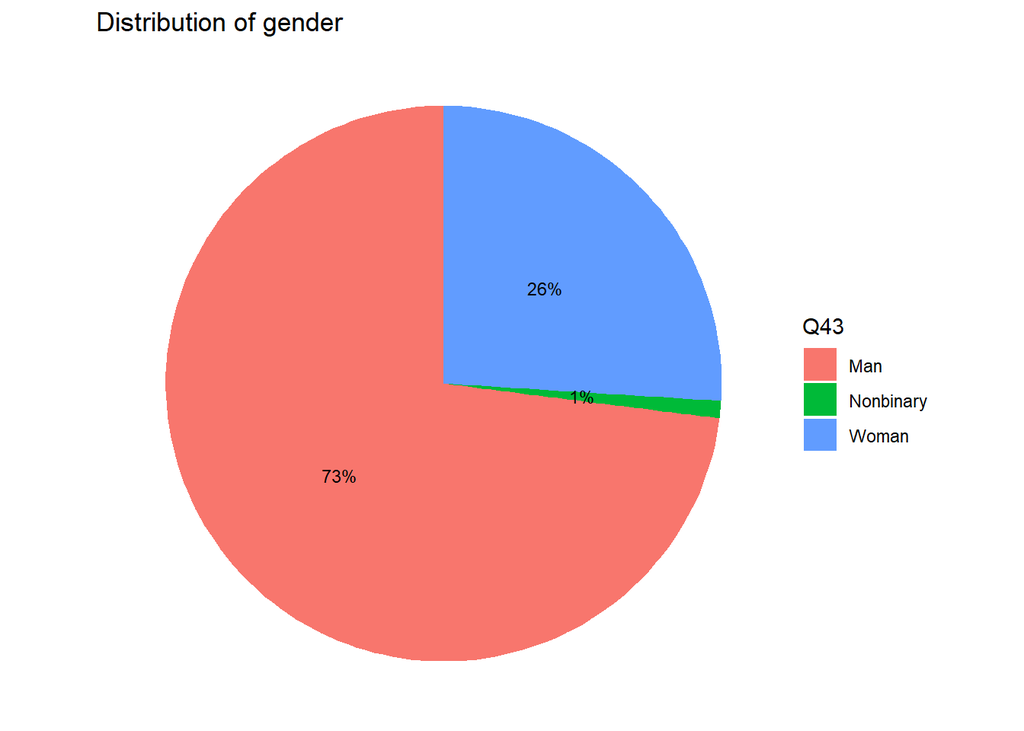

```
* Q45 - How would you best describe your race/ethnicity?
```

[output not shown]

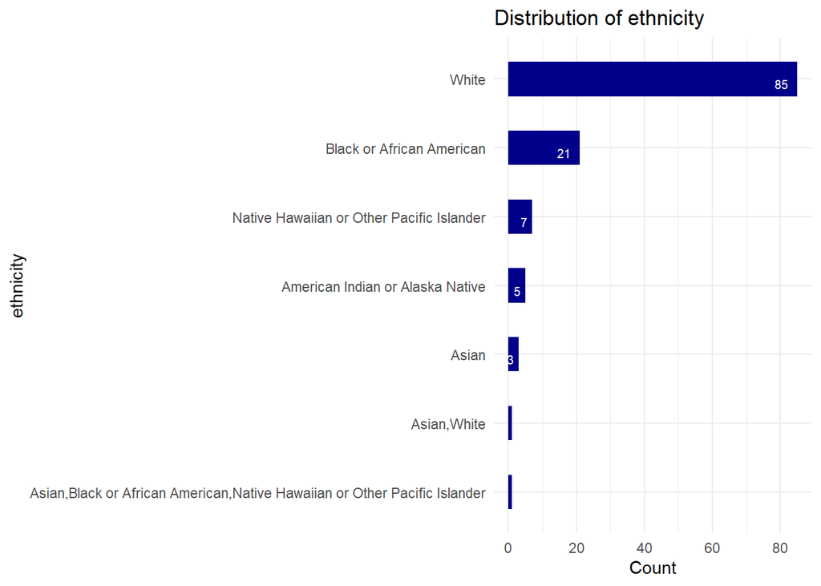

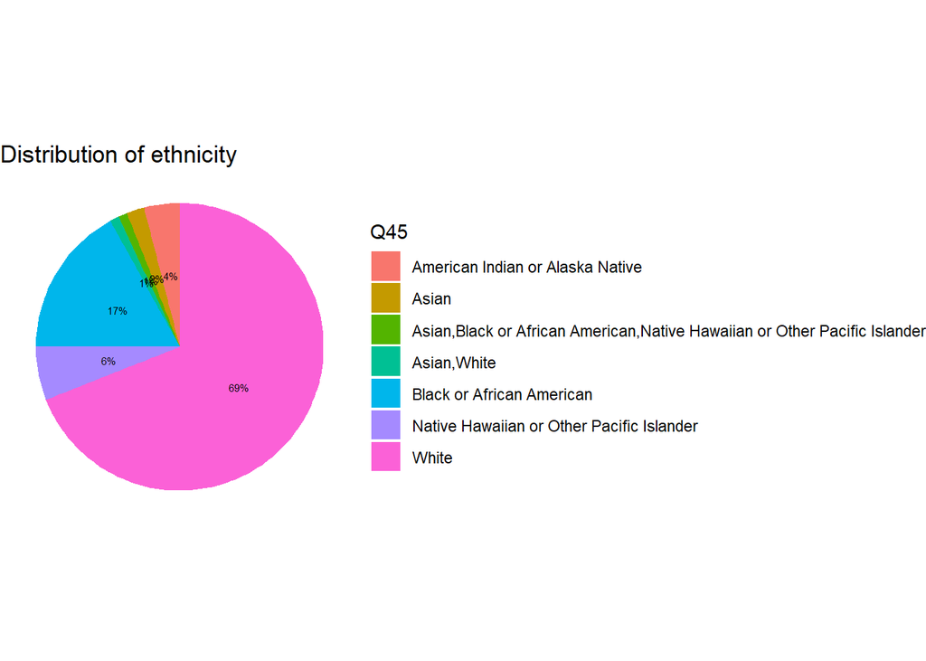

```
* Q46 - What is your highest level of education?
```

|  | Q46 | n | freq |
| --- | --- | --- | --- |
| 1 | Master's degree | 39 | 0.32 |
| 2 | Bachelor's degree | 35 | 0.28 |
| 3 | Doctorate | 26 | 0.21 |
| 4 | Associate degree | 10 | 0.08 |
| 5 | Technical or occupational certificate | 9 | 0.07 |
| 6 | High school diploma or equivalent | 3 | 0.02 |
| 7 | Prefer not to answer | 1 | 0.01 |

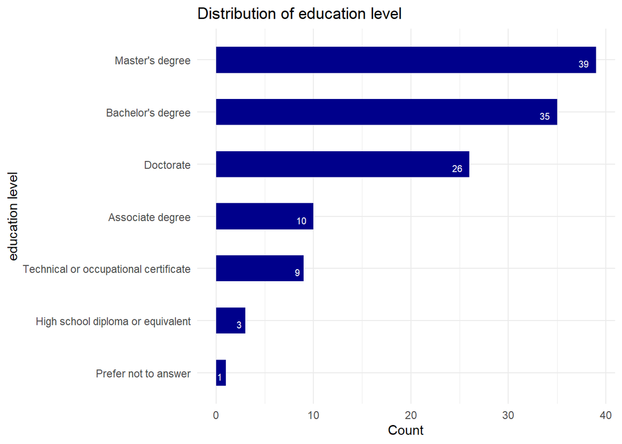

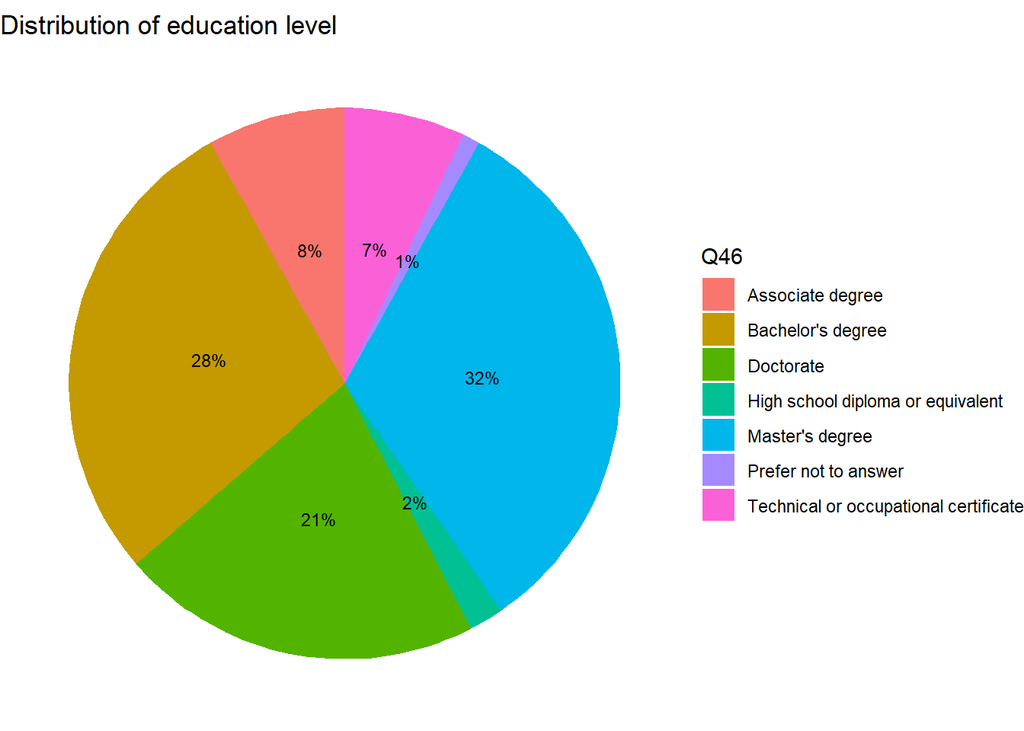

```
*    Q4 - Are you currently located in the United States?
```

|  | Q4 | n | freq |
| --- | --- | --- | --- |
| 1 | Yes | 122 | 0.99 |
| 2 | No | 1 | 0.01 |

```
* Q5 - Which of the following categories best describes your current employment status?
```

|  | Q5 | n | freq |
| --- | --- | --- | --- |
| 1 | Employed full time (40 hours or more per week) | 102 | 0.83 |
| 2 | Employed part time (up to 39 hours per week) | 16 | 0.13 |
| 3 | Self-employed | 2 | 0.02 |
| 4 | Unemployed and currently looking for work | 2 | 0.02 |
| 5 | Student | 1 | 0.01 |

```
* Q6 - How would you classify your most recent Computer and Information Technology
```

job? (check all that apply)

|  | Q6 | n | freq |
| --- | --- | --- | --- |
| 1 | Software/Web Developers | 76 | 0.22 |
| 2 | Computer Programmers | 60 | 0.17 |
| 3 | Software Testers | 42 | 0.12 |
| 4 | Software Quality Assurance Analysts | 36 | 0.1 |
| 5 | Computer Network Architects | 28 | 0.08 |
| 6 | Computer Systems Analysts | 26 | 0.08 |
| 7 | Computer and Information Research Scientists | 25 | 0.07 |
| 8 | Information Security Analysts | 16 | 0.05 |
| 9 | Computer Support Specialists | 12 | 0.03 |
| 10 | Network and Computer Systems Administrators | 11 | 0.03 |

[output cut: 2 more lines]

```
* Q11 - How would you classify the industry where you worked most recently as a software
```

engineer? (check all that apply)

|  | Q11 | n | freq |
| --- | --- | --- | --- |
| 1 | Computer and Information Technology | 61 | 0.5 |
| 2 | Business and Financial | 6 | 0.05 |
| 3 | Education/Training/Library | 5 | 0.04 |
| 4 | Management | 5 | 0.04 |
| 5 | Media and Communication | 5 | 0.04 |
| 6 | Production | 5 | 0.04 |
| 7 | Entertainment and Sports | 4 | 0.03 |
| 8 | Farming/Fishing/Forestry | 4 | 0.03 |
| 9 | Architecture and Engineering | 3 | 0.02 |
| 10 | Construction and Extraction | 3 | 0.02 |

[output cut: 12 more lines]

```
* Q12- How long have you worked as a software engineer?
```

|  | Q12 | n | freq |
| --- | --- | --- | --- |
| 1 | 1-5 years | 66 | 0.54 |
| 2 | 6-10 years | 34 | 0.28 |
| 3 | 11-15 years | 17 | 0.14 |
| 4 | Less than one year | 3 | 0.02 |
| 5 | More than 15 years | 3 | 0.02 |

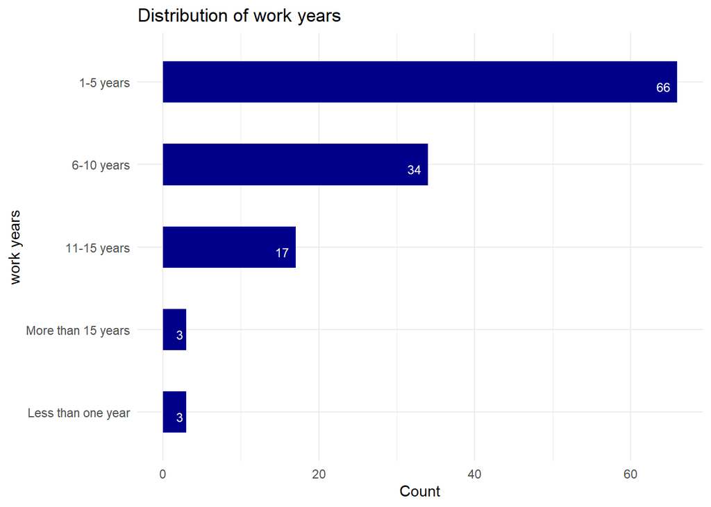

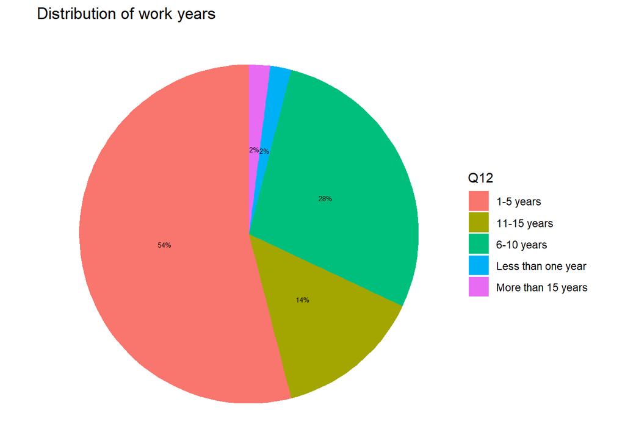

```
* Q13 - Which of the following tasks best describes the activities that you do/did in your role as a software engineer?
```

|  | Q13 | n | freq |
| --- | --- | --- | --- |
| 1 | Writing code | 84 | 0.16 |
| 2 | Testing new software programs | 76 | 0.14 |
| 3 | Optimizing software for speed and scalability | 70 | 0.13 |
| 4 | Testing and evaluating code | 66 | 0.12 |
| 5 | Designing software systems | 65 | 0.12 |
| 6 | Maintaining software systems | 63 | 0.12 |
| 7 | Evaluating software programs | 60 | 0.11 |
| 8 | Document aspects of an application or system as a reference | 55 | 0.1 |

### Usage patterns

```
* Q16- Have you used GenAI?
```

|  | Q16 | n | freq |
| --- | --- | --- | --- |
| 1 | Yes | 122 | 0.99 |
| 2 | No | 1 | 0.01 |

```
* Q17-What GenAI tools have you used for software engineering work? (check all that
```

apply)

|  | Q17 | n | freq |
| --- | --- | --- | --- |
| 1 | ChatGPT | 92 | 0.13 |
| 2 | Bing A.I | 68 | 0.1 |
| 3 | Bard | 64 | 0.09 |
| 4 | GitHub CoPilot | 62 | 0.09 |
| 5 | Sketch2Code | 49 | 0.07 |
| 6 | StarCoder | 49 | 0.07 |
| 7 | DeepCode | 47 | 0.07 |
| 8 | Anthropic Claude | 45 | 0.07 |
| 9 | Codewhisperer | 45 | 0.07 |
| 10 | Codey | 45 | 0.07 |

[output cut: 4 more lines]

```
* Q22 - What GenAI tools have you used to attain knowledge and skills for software
```

engineering work? (check all that apply)

|  | Q22 | n | freq |
| --- | --- | --- | --- |
| 1 | ChatGPT | 71 | 0.14 |
| 2 | Bard | 52 | 0.1 |
| 3 | Bing A.I | 50 | 0.1 |
| 4 | Anthropic Claude | 37 | 0.07 |
| 5 | TensorFlow | 37 | 0.07 |
| 6 | GitHub CoPilot | 36 | 0.07 |
| 7 | Sketch2Code | 36 | 0.07 |
| 8 | Codey | 34 | 0.07 |
| 9 | StarCoder | 34 | 0.07 |
| 10 | Codewhisperer | 33 | 0.06 |

[output cut: 3 more lines]

```
* Q18 - How often do/did you use GenAI tools for software engineering work? (na=have not used GenAI)
```

|  | Q18 | n | freq |
| --- | --- | --- | --- |
| 1 | Everyday | 69 | 0.57 |
| 2 | Several times a week | 44 | 0.36 |
| 3 | Once a week | 8 | 0.07 |
| 4 | Once a month | 1 | 0.01 |

### Needs - Goals

```
* Q19-What are/were your purposes for using GenAI tools in software engineering work? (check all that apply)
```

|  | Q19 | n | freq |
| --- | --- | --- | --- |
| 1 | Self-evaluating performances | 76 | 0.14 |
| 2 | Tackling new challenges | 71 | 0.13 |
| 3 | Starting work and getting in the flow of work quickly | 70 | 0.13 |
| 4 | Completing manual and repetitive work | 68 | 0.13 |
| 5 | Developing skills | 68 | 0.13 |
| 6 | Short-term problem-solving | 66 | 0.12 |
| 7 | Co-operating and interacting with colleagues | 58 | 0.11 |
| 8 | Long-term problem-solving | 57 | 0.11 |
| 9 | Other | 1 | 0 |

```
* Q20- How do you think the GenAI tools help you with software engineering work? (check all that apply
```

|  | Q20 | n | freq |
| --- | --- | --- | --- |
| 1 | I can attain knowledge and skills | 87 | 0.25 |
| 2 | I can improve quality of work | 65 | 0.18 |
| 3 | I can complete my work faster | 63 | 0.18 |
| 4 | I can enjoy my work more | 50 | 0.14 |
| 5 | I feel socially connected and supported | 48 | 0.14 |
| 6 | I can focus on the higher level of work instead of mundane and repetitive work | 41 | 0.12 |

```
* Q21 - In the previous question you indicated that "I can attain knowledge and skills" when using GenAI tools. In what practices do you want to use GenAI tools for the purpose of attaining knowledge and skills for software engineering? (check all that apply)
```

|  | Q21 | n | freq |
| --- | --- | --- | --- |
| 1 | Writing code | 64 | 0.15 |
| 2 | Testing new software programs | 57 | 0.13 |
| 3 | Optimizing software for speed and scalability | 55 | 0.13 |
| 4 | Maintaining software systems | 54 | 0.13 |
| 5 | Evaluating software programs | 52 | 0.12 |
| 6 | Testing and evaluating code | 52 | 0.12 |
| 7 | Designing software systems | 50 | 0.12 |
| 8 | Document aspects of an application or system as a reference | 46 | 0.11 |

```
* Q23 - In the previous question you indicated that "I can attain knowledge and skills" when using GenAI tools. What kind of knowledge and skills for software engineering work do you want to learn through the GenAI tools? (check all that apply)
```

|  | Q23 | n | freq |
| --- | --- | --- | --- |
| 1 | Tools and technologies for task performance | 63 | 0.18 |
| 2 | Knowledge of the field | 62 | 0.18 |
| 3 | Understanding issues and their contexts | 61 | 0.18 |
| 4 | Decision-making and problem-solving | 60 | 0.17 |
| 5 | Personal development | 53 | 0.15 |
| 6 | Working with others | 49 | 0.14 |

```
* Q24 - In the previous question you did not indicate "I can attain knowledge and skills"when using GenAI tools. Have you ever felt the need to attain knowledge and skills for software engineering work?
```

|  | Q24 | n | freq |
| --- | --- | --- | --- |
| 1 | Yes | 34 | 0.97 |
| 2 | No | 1 | 0.03 |

```
* Q25 - For what practices do you feel the need to attain knowledge and skills for software engineering work? (check all that apply)
```

|  | Q25 | n | freq |
| --- | --- | --- | --- |
| 1 | Writing code | 20 | 0.17 |
| 2 | Testing new software programs | 18 | 0.15 |
| 3 | Evaluating software programs | 16 | 0.13 |
| 4 | Maintaining software systems | 16 | 0.13 |
| 5 | Testing and evaluating code | 14 | 0.12 |
| 6 | Optimizing software for speed and scalability | 13 | 0.11 |
| 7 | Document aspects of an application or system as a reference | 12 | 0.1 |
| 8 | Designing software systems | 10 | 0.08 |
| 9 | Other | 1 | 0.01 |

```
* Q26 - What kind of knowledge and skills do you feel the need to learn for software
```

engineering work? (check all that apply)

|  | Q26 | n | freq |
| --- | --- | --- | --- |
| 1 | Decision-making and problem-solving | 22 | 0.22 |
| 2 | Knowledge of the field | 19 | 0.19 |
| 3 | Tools and technologies for task performance | 16 | 0.16 |
| 4 | Understanding issues and their contexts | 16 | 0.16 |
| 5 | Personal development | 14 | 0.14 |
| 6 | Working with others | 14 | 0.14 |

### Needs - values

```
* Q33 - Rate the level of importance of each of following items when considering the use of GenAI tools in learning (e.g., attaining knowledge and skills) during software engineering work (1: not important at all, 5: very important).
```

|  | Accountability | Reliability | Transparency | Fairness | Privacy | Security | Safety | Autonomy | Flexibility | Accessibility | Customization |
| --- | --- | --- | --- | --- | --- | --- | --- | --- | --- | --- | --- |
| Min | 1 | 2 | 1 | 2 | 2 | 2 | 1 | 1 | 2 | 1 | 1 |
| Max | 5 | 5 | 5 | 5 | 5 | 5 | 5 | 5 | 5 | 5 | 5 |
| Mean | 4.03 | 3.97 | 3.89 | 3.97 | 4.01 | 4.03 | 3.98 | 3.93 | 3.95 | 3.93 | 3.89 |
| StandardDeviation | 0.78 | 0.83 | 0.86 | 0.81 | 0.83 | 0.82 | 0.87 | 0.87 | 0.74 | 0.82 | 0.84 |
| Variance | 0.61 | 0.69 | 0.74 | 0.65 | 0.7 | 0.67 | 0.76 | 0.76 | 0.55 | 0.67 | 0.71 |

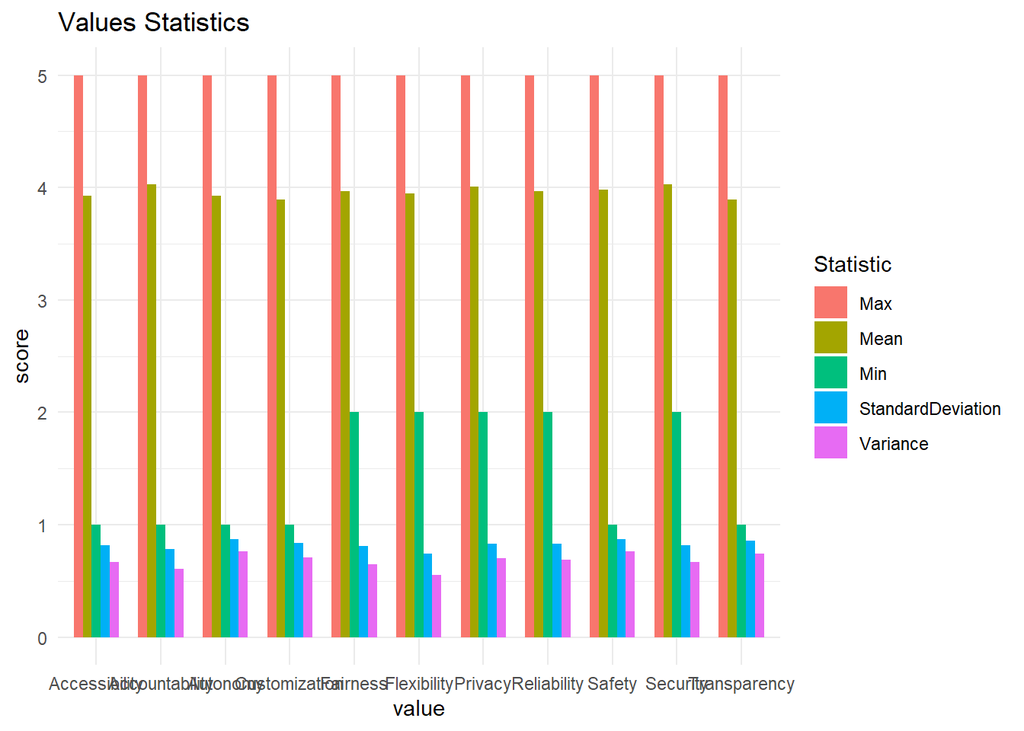

### Needs - Design aspirations

```
* Q36 - When do you want the GenAI tools to assist you in learning knowledge and skills
```

for software engineering work? (check all that apply)

|  | Q36 | n | freq |
| --- | --- | --- | --- |
| 1 | Before an action | 70 | 0.31 |
| 2 | During an action | 69 | 0.31 |
| 3 | After an action | 54 | 0.24 |
| 4 | When you need specific assistance | 30 | 0.13 |
| 5 | Other | 1 | 0 |

```
* Q37 - How do you want the GenAI tools to assist you in learning knowledge and skills for software engineering work? (check all that apply)
```

|  | Q37 | n | freq |
| --- | --- | --- | --- |
| 1 | Textually | 86 | 0.42 |
| 2 | Visually | 78 | 0.38 |
| 3 | Acoustically | 42 | 0.2 |

```
* Q38 -  Where do you want the GenAI tools to offer assistance for learning knowledge and skills for software engineering work? (e.g., information wrapped in tooltips)? (check all that apply)
```

|  | Q38 | n | freq |
| --- | --- | --- | --- |
| 1 | Document sidebars | 83 | 0.21 |
| 2 | Tables | 76 | 0.2 |
| 3 | Pop-ups | 69 | 0.18 |
| 4 | Tooltips | 60 | 0.16 |
| 5 | Visual effects | 53 | 0.14 |
| 6 | Sound effects | 45 | 0.12 |
| 7 | Others | 1 | 0 |

```
* Q39 -  Which aspects of learning for software engineering work can be improved more by the assistance of GenAI? (check all that apply)
```

|  | Q39 | n | freq |
| --- | --- | --- | --- |
| 1 | Knowledge of the field | 68 | 0.19 |
| 2 | Using effective tools and technologies for task performance | 68 | 0.19 |
| 3 | Understanding issues and their contexts | 63 | 0.17 |
| 4 | Personal development | 58 | 0.16 |
| 5 | Working with others | 57 | 0.16 |
| 6 | Decision-making and problem-solving | 48 | 0.13 |

### Wordcloud - open-end questions

```
* Q27 - What specific reasons do you have for not using GenAI technologies to learn new skills and information for software engineering work?
```

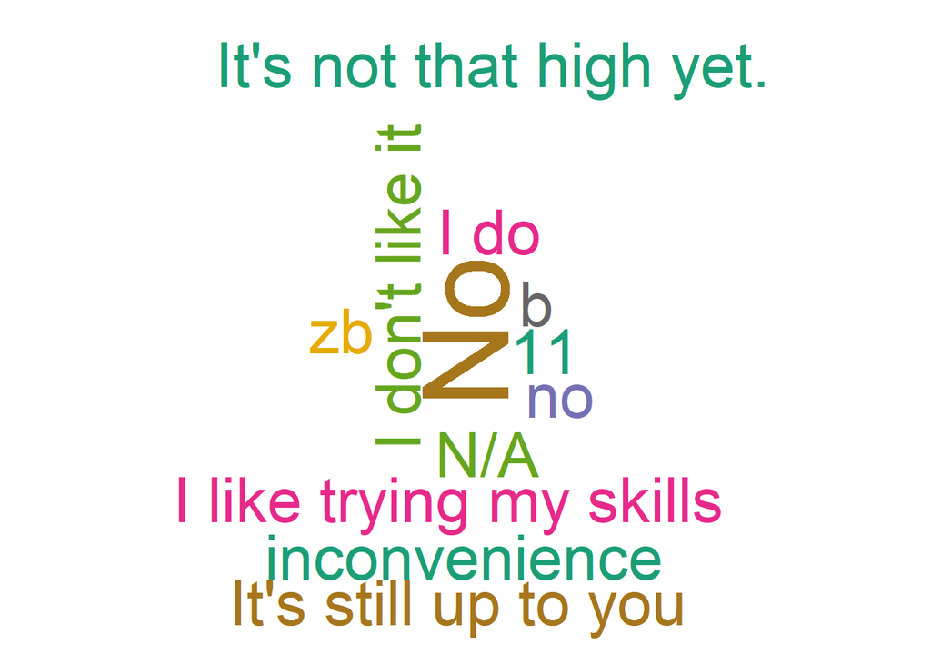

```
* Q28 - What other tools or methods do you use to attain knowledge and skills for software engineering work?
```

```r
q27 <- survey_c[,c("Q27")]
wc_q27 <-table(q27)
temp27<- sort(wc_q27, decreasing=T)
pal <- brewer.pal(8, "Dark2")
set.seed(405)
wordcloud(words = names(temp27),
          freq = temp27,
          min.freq = 1,
          max.words = Inf,
          random.order = FALSE,
          random.color = TRUE,
          rot.per = 0.1,
          scale = c(8, 0.2),
          colors = pal)
```

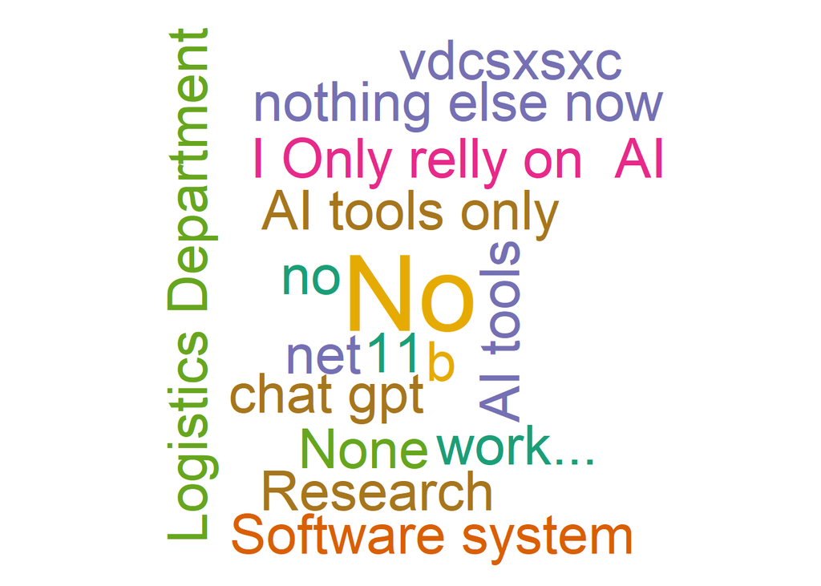

```
* Q34 - What other aspects are important for the use of GenAI to attain knowledge and skills for software engineering work?
```

```r
q28 <- survey_c[,c("Q28")]
wc_q28 <-table(q28)
temp28<- sort(wc_q28, decreasing=T)
pal <- brewer.pal(8, "Dark2")
set.seed(405)
wordcloud(words = names(temp28),
          freq = temp28,
          min.freq = 1,
          max.words = Inf,
          random.order = FALSE,
          random.color = TRUE,
          rot.per = 0.1,
          scale = c(8, 0.2),
          colors = pal)
```

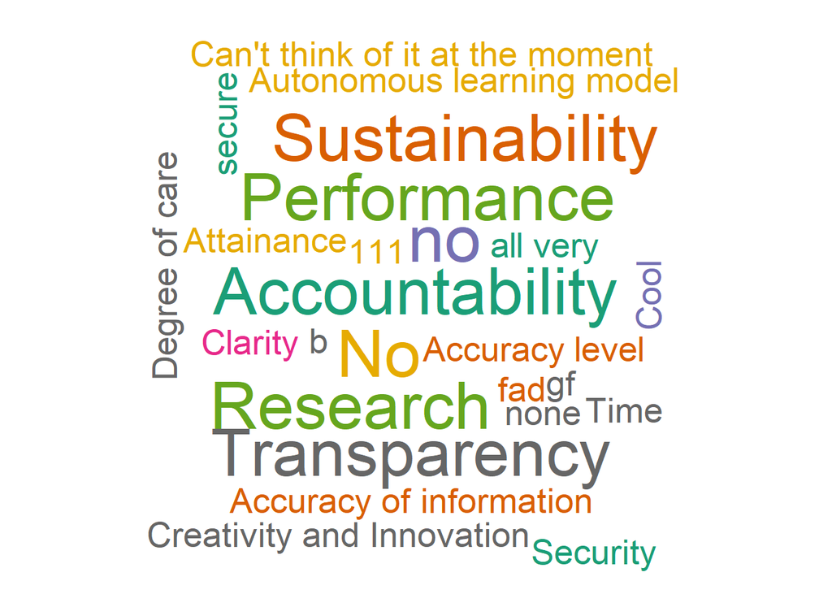

```
* Q40 - What other challenges have you faced when using GenAI tools for learning at the
```

```r
q34 <- survey_c[,c("Q34")]
wc_q34 <-table(q34)
temp34<- sort(wc_q34, decreasing=T)
pal <- brewer.pal(8, "Dark2")
set.seed(405)
wordcloud(words = names(temp34),
          freq = temp34,
          min.freq = 1,
          max.words = Inf,
          random.order = FALSE,
          random.color = TRUE,
          rot.per = 0.1,
          scale = c(8, 0.2),
          colors = pal)
```

workplace as a software engineer?

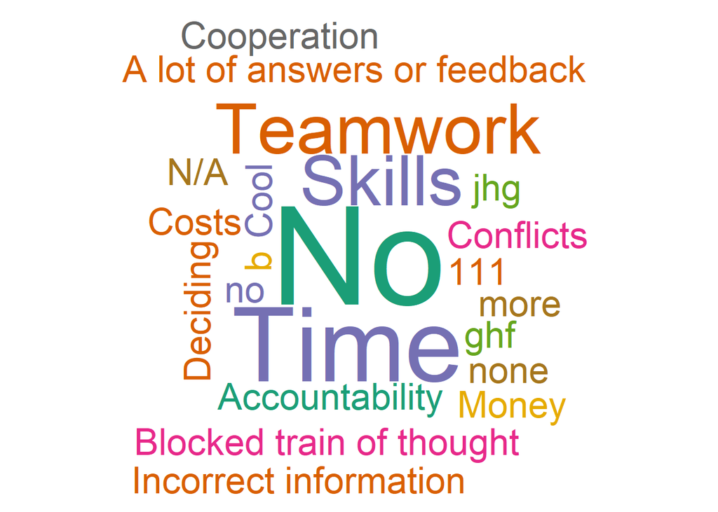

```r
q40 <- survey_c[,c("Q40")]
wc_q40 <-table(q40)
temp40<- sort(wc_q40, decreasing=T)
pal <- brewer.pal(8, "Dark2")
set.seed(405)
wordcloud(words = names(temp40),
          freq = temp40,
          min.freq = 1,
          max.words = Inf,
          random.order = FALSE,
          random.color = TRUE,
          rot.per = 0.1,
          scale = c(8, 0.2),
          colors = pal)
```

## Compare GenAI experiences & needs between different user groups

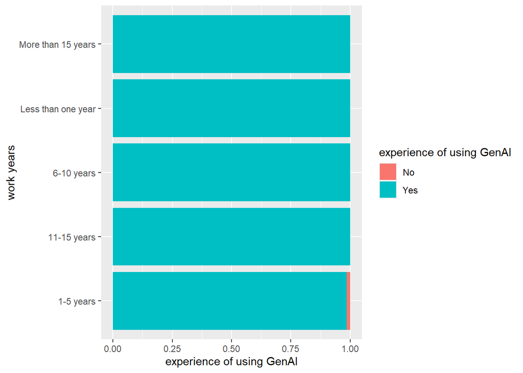

```r
##work years - experience of using GenAI
#Bar graph
#https://m.blog.naver.com/regenesis90/222203543999
q16 <- survey_c %>% filter(!is.na(Q16))
ggplot(q16,
       aes(x=Q12,
           fill=Q16))+
  geom_bar(position='fill')+
  coord_flip() +
  labs(x = "work years", y = "experience of using GenAI", fill = "experience of using GenAI")
```

```r
#Chi-square test (test of independence: If your data fails the sample size assumption, try collapsing categories to increase the expected frequencies. If that is not possible, an alternative test is Fisher’s Exact test.)
t_q12q16 <- table(survey_c$Q12, survey_c$Q16)
chisq.test(t_q12q16)$expected
```

```
                             No      Yes
  1-5 years          0.53658537 65.46341
  11-15 years        0.13821138 16.86179
  6-10 years         0.27642276 33.72358
  Less than one year 0.02439024  2.97561
  More than 15 years 0.02439024  2.97561
```

```r
chisq.test(t_q12q16,correct=FALSE)
```

```
    Pearson's Chi-squared test

data:  t_q12q16
X-squared = 0.87072, df = 4, p-value = 0.9287
```

```r
fisher.test(t_q12q16) #p-value = 1
```

```
    Fisher's Exact Test for Count Data

data:  t_q12q16
p-value = 1
alternative hypothesis: two.sided
```

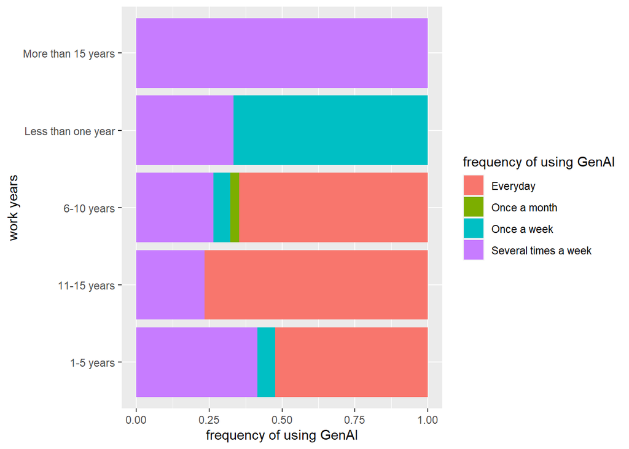

```r
##work years - frequency of using GenAI
#Bar graph
q18 <- survey_c %>% filter(!is.na(Q18))
ggplot(q18,
       aes(x=Q12,
           fill=Q18))+
  geom_bar(position='fill')+
  coord_flip() +
  labs(x = "work years", y = "frequency of using GenAI", fill = "frequency of using GenAI")
```

```r
#Chi-square test
t_q12q18 <- table(survey_c$Q12, survey_c$Q18)
chisq.test(t_q12q18)$expected
```

```
                      Everyday Once a month Once a week Several times a week
  1-5 years          36.762295   0.53278689   4.2622951            23.442623
  11-15 years         9.614754   0.13934426   1.1147541             6.131148
  6-10 years         19.229508   0.27868852   2.2295082            12.262295
  Less than one year  1.696721   0.02459016   0.1967213             1.081967
  More than 15 years  1.696721   0.02459016   0.1967213             1.081967
```

```r
chisq.test(t_q12q18,correct=FALSE)
```

```
    Pearson's Chi-squared test

data:  t_q12q18
X-squared = 31.216, df = 12, p-value = 0.001826
```

```r
fisher.test(t_q12q18) #p-value = 0.01012
```

```
    Fisher's Exact Test for Count Data

data:  t_q12q18
p-value = 0.01012
alternative hypothesis: two.sided
```

```r
##work years - purpose of using GenAI
practice3 <- practice %>% filter(!is.na(Q21))
t_q12q21 <- table(practice3$Q12, practice3$Q21)
chisq.test(t_q12q21)$expected
```

```
                     Designing software systems
  1-5 years                          23.8372093
  11-15 years                        10.2325581
  6-10 years                         14.4186047
  Less than one year                  0.8139535
  More than 15 years                  0.6976744

                     Document aspects of an application or system as a reference
  1-5 years                                                           21.9302326
  11-15 years                                                          9.4139535
  6-10 years                                                          13.2651163
  Less than one year                                                   0.7488372
  More than 15 years                                                   0.6418605

                     Evaluating software programs Maintaining software systems
  1-5 years                            24.7906977                   25.7441860
  11-15 years                          10.6418605                   11.0511628
  6-10 years                           14.9953488                   15.5720930
  Less than one year                    0.8465116                    0.8790698
  More than 15 years                    0.7255814                    0.7534884

                     Optimizing software for speed and scalability
  1-5 years                                             26.2209302
  11-15 years                                           11.2558140
  6-10 years                                            15.8604651
  Less than one year                                     0.8953488
  More than 15 years                                     0.7674419

                     Testing and evaluating code Testing new software programs
  1-5 years                           24.7906977                    27.1744186
  11-15 years                         10.6418605                    11.6651163
  6-10 years                          14.9953488                    16.4372093
  Less than one year                   0.8465116                     0.9279070
  More than 15 years                   0.7255814                     0.7953488

                     Writing code
  1-5 years            30.5116279
  11-15 years          13.0976744
  6-10 years           18.4558140
  Less than one year    1.0418605
  More than 15 years    0.8930233
```

```r
chisq.test(t_q12q21,correct=FALSE)
```

```
    Pearson's Chi-squared test

data:  t_q12q21
X-squared = 8.9195, df = 28, p-value = 0.9998
```

```r
fisher.test(t_q12q21, simulate.p.value = TRUE) #p-value = 1
```

```
    Fisher's Exact Test for Count Data with simulated p-value (based on
    2000 replicates)

data:  t_q12q21
p-value = 1
alternative hypothesis: two.sided
```

```r
##work years - GenAI tools
tool3 <- tool %>% filter(!is.na(Q22))
t_q12q22 <- table(tool3$Q12, tool3$Q22)
chisq.test(t_q12q22)$expected
```

```
                     Anthropic Claude      Bard   Bing A.I    ChatGPT
  1-5 years                16.1337209 22.674419 21.8023256 30.9593023
  11-15 years               9.0348837 12.697674 12.2093023 17.3372093
  6-10 years               10.7558140 15.116279 14.5348837 20.6395349
  Less than one year        0.7170543  1.007752  0.9689922  1.3759690
  More than 15 years        0.3585271  0.503876  0.4844961  0.6879845

                     Codewhisperer      Codey   DeepCode   EvoSuite
  1-5 years             14.3895349 14.8255814 14.3895349 13.5174419
  11-15 years            8.0581395  8.3023256  8.0581395  7.5697674
  6-10 years             9.5930233  9.8837209  9.5930233  9.0116279
  Less than one year     0.6395349  0.6589147  0.6395349  0.6007752
  More than 15 years     0.3197674  0.3294574  0.3197674  0.3003876

                     GitHub CoPilot Sketch2Code  StarCoder    Tabnine
  1-5 years              15.6976744  15.6976744 14.8255814 13.9534884
  11-15 years             8.7906977   8.7906977  8.3023256  7.8139535
  6-10 years             10.4651163  10.4651163  9.8837209  9.3023256
  Less than one year      0.6976744   0.6976744  0.6589147  0.6201550
  More than 15 years      0.3488372   0.3488372  0.3294574  0.3100775

                     TensorFlow
  1-5 years          16.1337209
  11-15 years         9.0348837
  6-10 years         10.7558140
  Less than one year  0.7170543
  More than 15 years  0.3585271
```

```r
chisq.test(t_q12q22,correct=FALSE)
```

```
    Pearson's Chi-squared test

data:  t_q12q22
X-squared = 22.485, df = 48, p-value = 0.9994
```

```r
fisher.test(t_q12q22, simulate.p.value = TRUE) #p-value = 0.9995
```

```
    Fisher's Exact Test for Count Data with simulated p-value (based on
    2000 replicates)

data:  t_q12q22
p-value = 1
alternative hypothesis: two.sided
```

```r
##work years - knowledge and skills
skill3 <- skill %>% filter(!is.na(Q23))
t_q12q23 <- table(skill3$Q12, skill3$Q23)
chisq.test(t_q12q23)$expected
```

```
                     Decision-making and problem-solving Knowledge of the field
  1-5 years                                    28.620690             29.5747126
  11-15 years                                  11.551724             11.9367816
  6-10 years                                   17.758621             18.3505747
  Less than one year                            1.206897              1.2471264
  More than 15 years                            0.862069              0.8908046

                     Personal development
  1-5 years                    25.2816092
  11-15 years                  10.2040230
  6-10 years                   15.6867816
  Less than one year            1.0660920
  More than 15 years            0.7614943

                     Tools and technologies for task performance
  1-5 years                                           30.0517241
  11-15 years                                         12.1293103
  6-10 years                                          18.6465517
  Less than one year                                   1.2672414
  More than 15 years                                   0.9051724

                     Understanding issues and their contexts
  1-5 years                                       29.0977011
  11-15 years                                     11.7442529
  6-10 years                                      18.0545977
  Less than one year                               1.2270115
  More than 15 years                               0.8764368

                     Working with others
  1-5 years                   23.3735632
  11-15 years                  9.4339080
  6-10 years                  14.5028736
  Less than one year           0.9856322
  More than 15 years           0.7040230
```

```r
chisq.test(t_q12q23,correct=FALSE)
```

```
    Pearson's Chi-squared test

data:  t_q12q23
X-squared = 7.5673, df = 20, p-value = 0.9944
```

```r
fisher.test(t_q12q23, simulate.p.value = TRUE) #p-value = 0.9945
```

```
    Fisher's Exact Test for Count Data with simulated p-value (based on
    2000 replicates)

data:  t_q12q23
p-value = 0.9945
alternative hypothesis: two.sided
```

```r
##work years - accountability rating
#mean value
survey_c %>%
  group_by(Q12) %>%
  summarise(Mean_Q33_1 = mean(Q33_1, na.rm = TRUE),
            Mean_Q33_2 = mean(Q33_2, na.rm = TRUE),
            Mean_Q33_3 = mean(Q33_3, na.rm = TRUE),
            Mean_Q33_4 = mean(Q33_4, na.rm = TRUE),
            Mean_Q33_5 = mean(Q33_5, na.rm = TRUE),
            Mean_Q33_6 = mean(Q33_6, na.rm = TRUE),
            Mean_Q33_7 = mean(Q33_7, na.rm = TRUE),
            Mean_Q33_8 = mean(Q33_8, na.rm = TRUE),
            Mean_Q33_9 = mean(Q33_9, na.rm = TRUE),
            Mean_Q33_10 = mean(Q33_10, na.rm = TRUE),
            Mean_Q33_11 = mean(Q33_11, na.rm = TRUE)
            )
```

```
# A tibble: 5 × 12
  Q12          Mean_Q33_1 Mean_Q33_2 Mean_Q33_3 Mean_Q33_4 Mean_Q33_5 Mean_Q33_6
  <chr>             <dbl>      <dbl>      <dbl>      <dbl>      <dbl>      <dbl>
1 1-5 years          4.03       3.95       3.88       3.98       4.05       4.06
2 11-15 years        4.35       4.35       3.94       4          4.18       3.94
3 6-10 years         4          3.82       3.91       3.97       3.88       4.09
4 Less than o…       3          3.67       2.67       3.67       3.33       3
5 More than 1…       3.67       4          4.67       3.67       4.33       4.33
# ℹ 5 more variables: Mean_Q33_7 <dbl>, Mean_Q33_8 <dbl>, Mean_Q33_9 <dbl>,
#   Mean_Q33_10 <dbl>, Mean_Q33_11 <dbl>
```

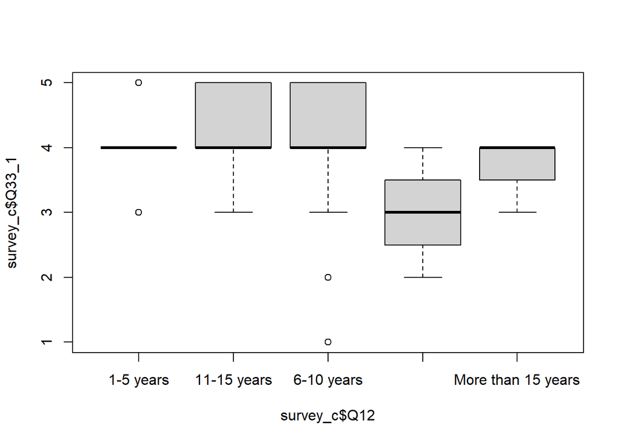

```r
#ANOVA (does not satisfy assumptions)
boxplot(survey_c$Q33_1~survey_c$Q12)
```

```r
leveneTest(survey_c$Q33_1~survey_c$Q12)
```

```
Levene's Test for Homogeneity of Variance (center = median)
       Df F value Pr(>F)
group   4  0.8097 0.5214
      118
```

```r
aov_q12_1 <- aov(survey_c$Q33_1~survey_c$Q12)
aov_q12_1
```

```
Call:
   aov(formula = survey_c$Q33_1 ~ survey_c$Q12)

Terms:
                survey_c$Q12 Residuals
Sum of Squares       5.38151  68.48841
Deg. of Freedom            4       118

Residual standard error: 0.7618466
Estimated effects may be unbalanced
```

```r
TukeyHSD(aov_q12_1)
```

```
  Tukey multiple comparisons of means
    95% family-wise confidence level

Fit: aov(formula = survey_c$Q33_1 ~ survey_c$Q12)

$`survey_c$Q12`
                                             diff        lwr        upr
11-15 years-1-5 years                  0.32263815 -0.2514180  0.8966943
6-10 years-1-5 years                  -0.03030303 -0.4758570  0.4152509
Less than one year-1-5 years          -1.03030303 -2.2762619  0.2156558
More than 15 years-1-5 years          -0.36363636 -1.6095952  0.8823225
6-10 years-11-15 years                -0.35294118 -0.9798912  0.2740088
Less than one year-11-15 years        -1.35294118 -2.6746678 -0.0312145
More than 15 years-11-15 years        -0.68627451 -2.0080012  0.6354522
Less than one year-6-10 years         -1.00000000 -2.2711960  0.2711960
More than 15 years-6-10 years         -0.33333333 -1.6045293  0.9378627
More than 15 years-Less than one year  0.66666667 -1.0566541  2.3899874
                                          p adj
11-15 years-1-5 years                 0.5278143
6-10 years-1-5 years                  0.9997145
Less than one year-1-5 years          0.1551289
More than 15 years-1-5 years          0.9275403
6-10 years-11-15 years                0.5261847
Less than one year-11-15 years        0.0420651
More than 15 years-11-15 years        0.6042213
Less than one year-6-10 years         0.1947528
More than 15 years-6-10 years         0.9499731
More than 15 years-Less than one year 0.8206503
```

```r
#Kruskal-Wallis (KW) test: nonparametric test based on ranks
kruskal.test(survey_c$Q33_1~survey_c$Q12)
```

```
    Kruskal-Wallis rank sum test

data:  survey_c$Q33_1 by survey_c$Q12
Kruskal-Wallis chi-squared = 7.7868, df = 4, p-value = 0.09971
```

```
* Q11. Industry where SE works - experience of using GenAI/frequency of using GenAI/purpose of using GenAI/GenAI tools they use/knowledge and skills they want to learn/values rating/design aspirations

* Q13. Task SE conducts - experience of using GenAI/frequency of using GenAI/purpose of using GenAI/GenAI tools they use/knowledge and skills they want to learn/values rating/design aspirations

* Demograhpic feature (age, gender, ethnicity, education level) - experience of using GenAI/frequency of using GenAI/purpose of using GenAI/GenAI tools they use/knowledge and skills they want to learn/values rating/design aspirations
```